# Explore_bikeshare_data

### Question 2

**Popular stations and trip**

- What is the most common start station for each city?

```r
# Use the earlier function to create a data frame of start stations by city
start_stations = rbind(df_2(chi$Start.Station, 'Start.Station', 'Chicago'),
              df_2(ny$Start.Station, 'Start.Station', 'New York'),
              df_2(wash$Start.Station, 'Start.Station', 'Washington'))
```

```r
# This function takes in a data frame and city name and returns the 5 most popular starts and their count
common_starts = function(df, City.Name) {
    city_data = df[df$City == City.Name, ]
    station_counts = table(city_data$Start.Station)
    station_counts = data.frame(sort(station_counts, decreasing = TRUE)[1:5])
    names(station_counts) = c(paste('Start.Station'), ('Count'))
    return(station_counts)
}
```

```r
# Run the function for each city
chi_starts = common_starts(start_stations, "Chicago")
ny_starts = common_starts(start_stations, 'New York')
wash_starts = common_starts(start_stations, 'Washington')

chi_starts
ny_starts
wash_starts
```

| Start.Station | Count |
| --- | --- |
| Streeter Dr & Grand Ave | 210 |
| Lake Shore Dr & Monroe St | 140 |
| Clinton St & Washington Blvd | 120 |
| Clinton St & Madison St | 102 |
| Canal St & Adams St | 101 |

| Start.Station | Count |
| --- | --- |
| Pershing Square North | 592 |
| W 21 St & 6 Ave | 385 |
| Broadway & E 22 St | 383 |
| E 17 St & Broadway | 380 |
| West St & Chambers St | 364 |

| Start.Station | Count |
| --- | --- |
| Columbus Circle / Union Station | 1700 |
| Lincoln Memorial | 1546 |
| Jefferson Dr & 14th St SW | 1488 |
| Massachusetts Ave & Dupont Circle NW | 1219 |
| Jefferson Memorial | 1068 |

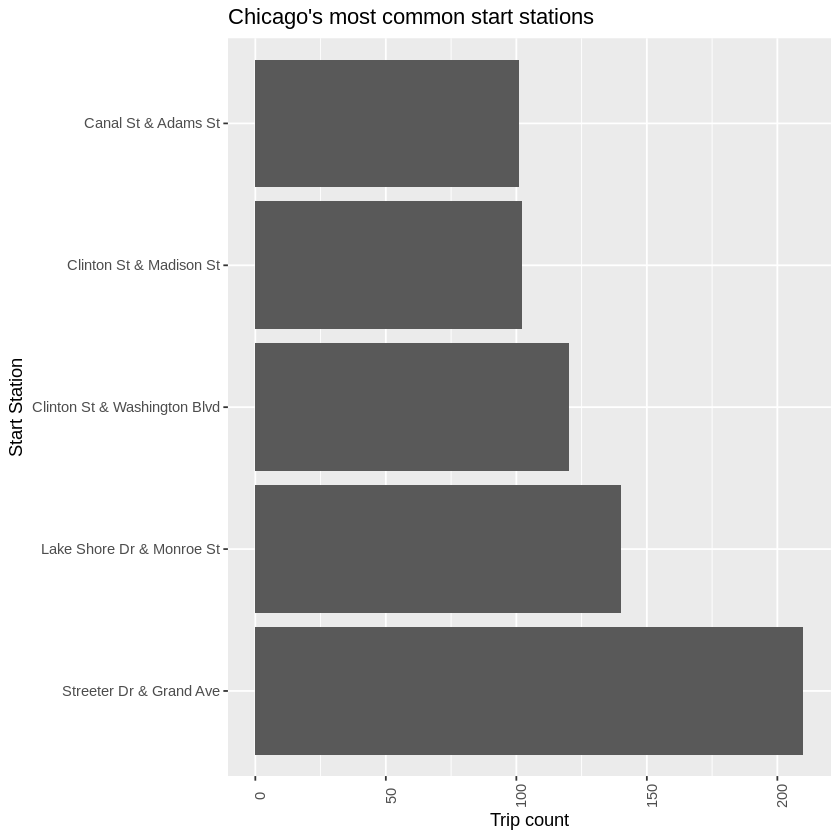

```r
# Plot for Chicago
ggplot(data=chi_starts, aes(x=Start.Station, y=Count)) +
    geom_bar(stat="identity") +
    theme(axis.text.x = element_text(angle = 90)) +
    coord_flip() +
    ggtitle('Chicago\'s most common start stations') +
    xlab('Start Station') +
    ylab('Trip count')
```

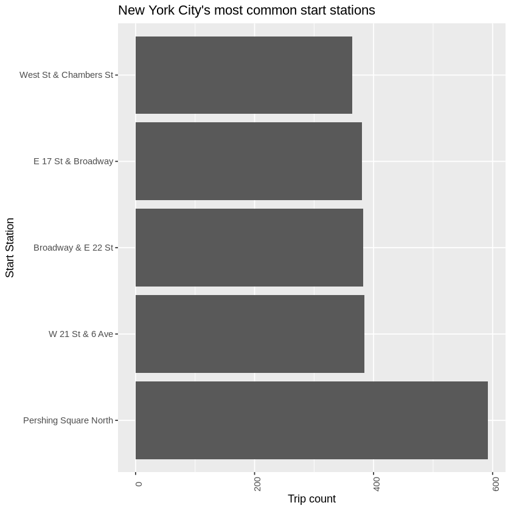

```r
#Plot for New York
ggplot(data=ny_starts, aes(x=Start.Station, y=Count)) +
    geom_bar(stat="identity") +
    theme(axis.text.x = element_text(angle = 90)) +
    coord_flip() +
    ggtitle('New York City\'s most common start stations') +
    xlab('Start Station') +
    ylab('Trip count')
```

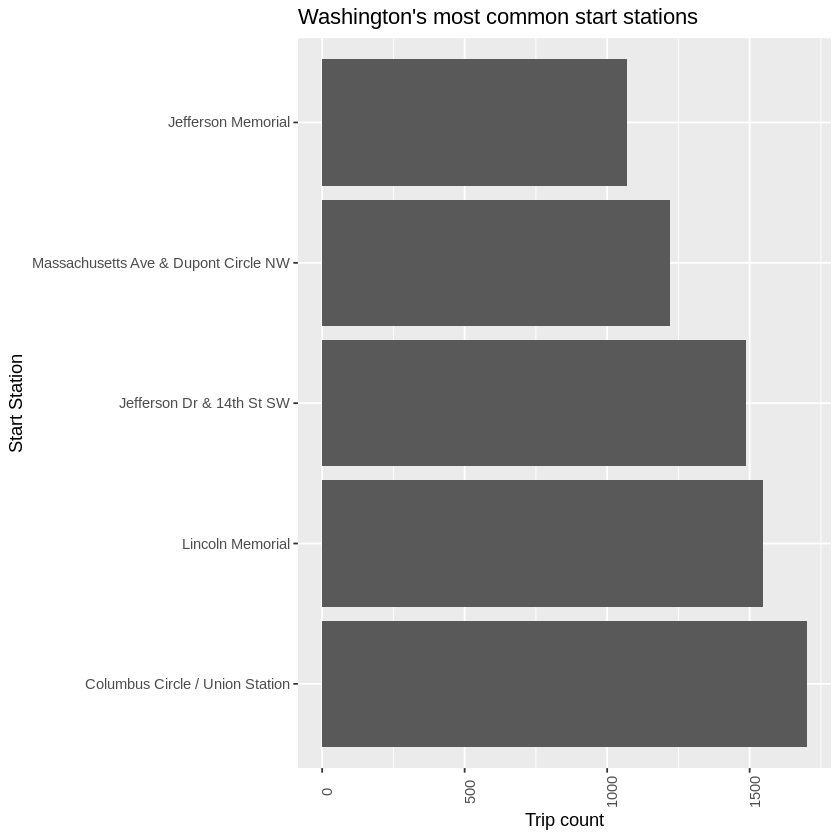

```r
# Plot for Washington
ggplot(data=wash_starts, aes(x=Start.Station, y=Count)) +
    geom_bar(stat="identity") +
    theme(axis.text.x = element_text(angle = 90)) +
    coord_flip() +
    ggtitle('Washington\'s most common start stations') +
    xlab('Start Station') +
    ylab('Trip count')
```

**Here are the final counts for the top five start stations for each city.**

**Chicago**

- Streeter Dr & Grand Ave 210
- Lake Shore Dr & Monroe St 140
- Clinton St & Washington Blvd 120
- Clinton St & Madison St 102
- Canal St & Adams St 101

### Question 3

**Trip duration**

- What is the average travel time for users based on type of user?
- What is the average travel time for users based on city?

```r
# I want to combine all three data sets into one.  This creates Birth.Year and Gender columns for Washington with null values
# Now each table has the same number of columns
wash$Gender = NA
wash$Birth.Year = NA
```

```r
# Function that concatenates data frames
combine = function(df1, df2) {
    return(rbind(df1,df2))
}
```

```r
# Adding a column for city name to use later
ny$City = 'New York City'
wash$City = 'Washington'
chi$City = 'Chicago'

# Combining each data frame into one
cities = combine(ny,wash)
cities = combine(cities,chi)
```

```r
head(cities)
```

[output not shown]

```r
# Initial summary of Trip Duration
summary(cities$Trip.Duration)
```

```
   Min. 1st Qu.  Median    Mean 3rd Qu.    Max.    NA's
     60     392     667    1098    1159 1088634       2
```

```r
# Removing columns where there is no value for Subscriber or Customer
cities = cities[cities$User.Type %in% c("Subscriber", "Customer"),]

# Converting Trip Duration to minutes so it's easier to understand
cities$Trip.Duration = cities$Trip.Duration / 60
```

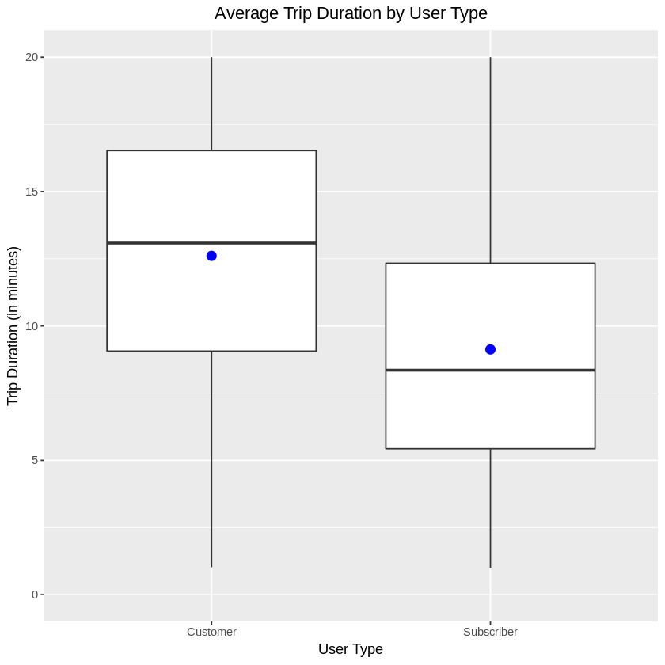

```r
# Box plot for Trip Duration and User Type comparison
# Source used for help with box plot formatting http://www.sthda.com/english/wiki/ggplot2-legend-easy-steps-to-change-the-position-and-the-appearance-of-a-graph-legend-in-r-software
# Source used for help centering title https://stackoverflow.com/questions/40675778/center-plot-title-in-ggplot2
ggplot(cities, aes(x=User.Type, y=Trip.Duration)) +
    geom_boxplot() +
    stat_summary(geom='point', color='blue', size=3) +
    ylim(0,20) +
    xlab('User Type') +
    ylab('Trip Duration (in minutes)') +
    ggtitle('Average Trip Duration by User Type') +
    theme(plot.title = element_text(hjust = 0.5))
```

[figure not shown]

```r
ggplot(cities, aes(x=City, y=Trip.Duration)) +
    geom_boxplot() +
    stat_summary(geom='point', color='blue', size=3) +
    ylim(0,20) +
    xlab('User Type') +
    ylab('Trip Duration (in minutes)') +
    ggtitle('Average Trip Duration by City') +
    theme(plot.title = element_text(hjust = 0.5))
```

**Trip Duration by User Type**

- Customers actually had a higher average trip duration than subscribers. Looking at the max value in summary, this could be due to severe outliers. Further Data Wrangling might be necessary here
- If the outliers did not skew the data then subscribers might use the bikes more often and just take shorter trips

**Trip Duration by City**

- All cities had very close results for each quartile and the mean. There's not a large difference between them.

## Finishing Up

> Congratulations! You have reached the end of the Explore Bikeshare Data Project. You should be very proud of all you have accomplished!

> **Tip**: Once you are satisfied with your work here, check over your report to make sure that it is satisfies all the areas of the [rubric](https://review.udacity.com/#!/rubrics/2508/view).

## Directions to Submit

> Before you submit your project, you need to create a .html or .pdf version of this notebook in the workspace here. To do that, run the code cell below. If it worked correctly, you should get a return code of 0, and you should see the generated .html file in the workspace directory (click on the orange Jupyter icon in the upper left).

> Alternatively, you can download this report as .html via the **File** > **Download as** submenu, and then manually upload it into the workspace directory by clicking on the orange Jupyter icon in the upper left, then using the Upload button.

> Once you've done this, you can submit your project by clicking on the "Submit Project" button in the lower right here. This will create and submit a zip file with this .ipynb doc and the .html or .pdf version you created. Congratulations!

```r
system('python -m nbconvert Explore_bikeshare_data.ipynb')
```